# Practical on trajectory types

Dirk Wulff

## Overview

In this practical you’ll learn how to analyze your mouse-tracking data based on trajectory types. After this practical, you will be able to

1. Explore the types in your data using illustrations and explorative clustering.
2. Identify and match your data to prototype-trajectories.
3. Compare you experimental conditions using trajectory types.

For every step in this practical, code will be provided that demonstrates the individual steps for the data of Spivey et al. (2005).

## Tasks

### A - Load in, import and process your data

You should know how to do this. Don’t forget to load `mousetrap`.

```r
# load mousetrap
library(mousetrap)

# read data from file
spivey <- readr::read_csv('spivey.csv')

# look at data
print(spivey)
```

```
# A tibble: 60,558 x 8
   paper        ptp trial     t     x     y condition target.location
   <chr>      <int> <int> <int> <int> <int> <chr>     <chr>
 1 Spivey2005     1     7   132   503   103 cohort    left
 2 Spivey2005     1     7   149   503   111 cohort    left
 3 Spivey2005     1     7   165   503   120 cohort    left
 4 Spivey2005     1     7   186   504   162 cohort    left
 5 Spivey2005     1     7   215   504   201 cohort    left
 6 Spivey2005     1     7   232   506   243 cohort    left
 7 Spivey2005     1     7   248   508   266 cohort    left
 8 Spivey2005     1     7   266   509   311 cohort    left
 9 Spivey2005     1     7   282   509   335 cohort    left
10 Spivey2005     1     7   298   509   353 cohort    left
# ... with 60,548 more rows
```

```r
# import into mousetrap
spivey_mt <- mt_import_long(spivey,xpos_label = 'x',
                            ypos_label = 'y',
                            timestamps_label = 't',
                            mt_id_label = c('ptp', 'trial'))

# align start points
spivey_mt <- mt_align_start(spivey_mt)

# flip to one side
spivey_mt <- mt_remap_symmetric(spivey_mt)

# align to mt space
spivey_mt <- mt_align(spivey_mt, coordinates = 'mt')
```

### B - Explore your data using animations and plots

Create an animation of your data using `mt_animate()`. The `.gif` file is created in your working directory, which should be your project folder. If you can’t find it try `getwd()`, which will tell you your current working directory. Try playing around with functions arguments, such as `seconds`, `speed`, and `density`. Check out `?mt_animate`.

```r
# create animation
mt_animate(spivey_mt,
           density = 5,
           seconds = 1)
```

Create a heatmap of your data using `mt_heatmap()`. Again try playing around with the function arguments, such as `xres` and `colors`. Check out `?mt_heatmap` and `?mt_heatmap_raw`.

Advanced: Try to add velocity as a third dimension represented by color.

```
spatializing trajectories
calculate image
smooth image
enhance image by 49.2
```

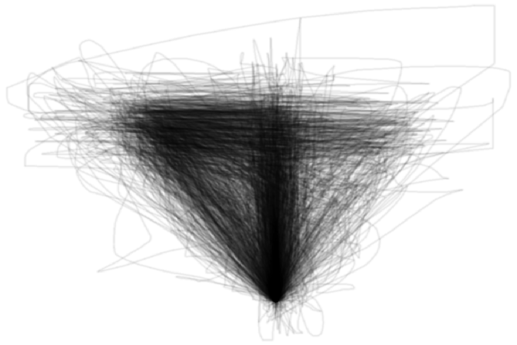

```r
# create heat map
mt_heatmap(spivey_mt,
           xres = 1000,
           colors = c('white', 'black'),
           verbose = FALSE)
```

### C - Explore your data using explorative clustering

Cluster your data using `mt_cluster()`. To do this, first calculate the spatialized trajectories using `mt_spatialize()`. Then use `mt_cluster()` to cluster the trajectories. Choose some number of clusters between 3 and 10 and assign that value to the `n_cluster`-argument. The cluster assignments will be stored in a new element in the mousetrap object. Find out how it is called using `names()`.

Advanced: Try do determine the appropriate number of clusters using `mt_cluster_k()`

```r
# calculate spatialized trajectories
spivey_mt <- mt_spatialize(spivey_mt)

# cluster trajectories.
spivey_mt <- mt_cluster(spivey_mt, n_cluster = 5)

# show element names
names(spivey_mt)
```

```
[1] "data"            "trajectories"    "sp_trajectories" "clustering"
```

Separately plot clusters using `mt_heatmap_ggplot()`. In comparison to the original `mt_heatmap()`-function, this function allows you to easily create separate plots using the `facetin`-functionality from `ggplot2`.

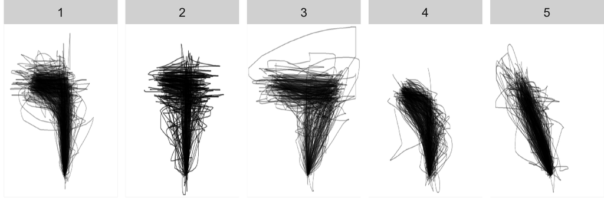

```r
# plot prototype mappings
mt_heatmap_ggplot(spivey_mt,
                  xres = 1000,
                  use2 = 'clustering',
                  facet_col = 'cluster',
                  colors = c('white', 'black'),
                  verbose = FALSE)
```

Now, try out different numbers of clusters to find the most appropriate separation of trajectories into clusters. For the data of Spivey et al. one may argue that this number is in fact 5.

### D - Analyze your data using prototype matching

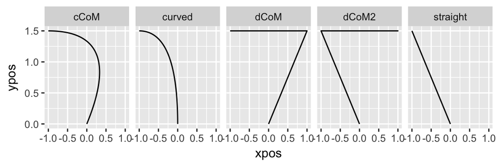

```r
# plot prototypes
mt_plot(mt_prototypes, facet_col = 'mt_id')
```

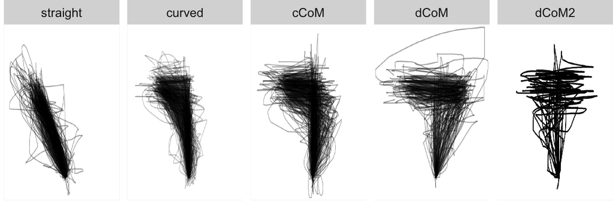

```r
# map to prototypes
spivey_mt <- mt_map(spivey_mt)

# plot prototype mappings
mt_heatmap_ggplot(spivey_mt,
                  xres = 1000,
                  use2 = 'prototyping',
                  facet_col = 'prototype_label',
                  colors = c('white', 'black'),
                  verbose = FALSE)
```

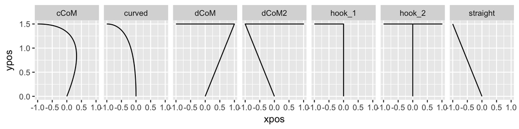

```r
# extract prototypes
mt_prototypes_ext <- mt_prototypes

# Add additional prototypes
mt_prototypes_ext <- mt_add_trajectory(
   mt_prototypes,
   xpos = c(0, 0, -1),
   ypos = c(0, 1.5, 1.5),
   id = "hook_1"
)
mt_prototypes_ext <- mt_add_trajectory(
   mt_prototypes_ext,
   xpos = c(0, 0, 1, -1),
   ypos = c(0, 1.5, 1.5, 1.5),
   id = "hook_2"
)

# plot prototypes
mt_plot(mt_prototypes_ext, facet_col = 'mt_id')
```

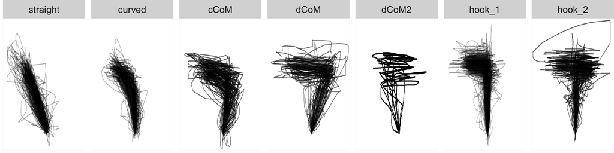

```r
# map to prototypes
spivey_mt <- mt_map(spivey_mt, prototypes = mt_prototypes_ext)
# plot prototype mappings
mt_heatmap_ggplot(spivey_mt,
                  xres = 1000,
                  use2 = 'prototyping',
                  facet_col = 'prototype_label',
                  colors = c('white', 'black'),
                  verbose = FALSE)
```

### E - Compare conditions using prototype matching

Ok, so far we have mainly been concerned with finding a good assignment of trajectories to types. Now, we want to reap the benefits by using the assignment to test and qualify the effect of conditions. There is multiple ways to do this. The most simply is to compare the relative frequencies of different types across conditions using a chisquare test. Use the `chisq.test()`-function to compare the distributions of types across conditions. Unfortunately, this requires a little bit of data wrangling…

```r
# exctract conditional tables of mappings
cond_types <- tapply(
  spivey_mt$prototyping$prototype,
  spivey_mt$data$condition,
  table)

# create contingency table
cond_types_ctab <- do.call(rbind, cond_types)

# print contingency table
print(cond_types_ctab)
```

```
          1   2  3  4 5   6  7
cohort  148 140 67 57 5 187 68
control 181 165 64 22 6 170 14
```

```r
# test for independence
chisq.test(cond_types_ctab)
```

```
    Pearson's Chi-squared test

data:  cond_types_ctab
X-squared = 55.547, df = 6, p-value = 3.595e-10
```

For Spivey et al.’s data, the chisquare test showed systematic differences in the relative frequency distributions of types. Next, which types contributed most. Put differently, which type frequencies differ most across conditions? Assess this via the residuals of the chisquare test. Simply store the result of the test in an object and access the `residuals` element. Which type produced the largest residual?

```r
# store chisq test object
chisq_test <- chisq.test(cond_types_ctab)

# print residuals
print(chisq_test$residuals)
```

```
                1         2          3         4          5          6
cohort  -1.748597 -1.461421 -0.1249880  2.493878 -0.2981143  0.1177126
control  1.817520  1.519024  0.1299146 -2.592177  0.3098648 -0.1223523
                7
cohort   3.894743
control -4.048258
```

Finally, evaluate the relationship between types and classic curvature comparisons. Does the average curvature differ between conditions for trajectory types that are consistent with Spivey et al.’s interpretation of mousetracking, i.e., trajectories that do not exhibit obvious discontinuities or kinks? For Spivey et al.’s data, those trajectories are represented by the `straight`, `curved`, and `cCoM` types. Use `mt_subset`, `mt_measures`, and `mt_aggregate` to compute the average mean absolute deviation (MAD) per condition and evaluate the effect size.

```r
# store chisq test object
spivey_mt_subset <- mt_subset(spivey_mt,
                              check = 'prototyping',
                              prototype_label %in% c('straight','curved','cCoM'))

# mt measures
spivey_mt_subset <- mt_measures(spivey_mt_subset)

# compute aggregate measures
mt_aggregate(spivey_mt_subset,
             use_variables = 'MAD',
             use2_variables = 'condition',
             .funs = c('mean', 'sd'))
```

```
  condition      mean        sd
1    cohort 0.3877966 0.4162386
2   control 0.3503166 0.3874504
```